# Example3

Hwang Seong-Yun

2020 11 9

### 필요 패키지

```r
library(tidyverse)
library(mgcv)
```

```r
library(ggplot2)
library(gridExtra)
library(moonBook)
library(ztable)
library(survival)
library(ggGam)
library(corrplot)
library(ggcorrplot)
library(car)
library(lmtest)
library(fda)
library(refund)
```

### 사용데이터 : 광산 지점 데이터

#### 모니터링 기간 : 2010~2019년 (일별 주단위자료)

#### 반응변수 : Chla

#### 설명변수 : pH, DO, BOD, COD, SS, TN, TP, TOC, WT, EC, TC, NH3N, PO4P, FC, Flow, Rain

#### 수질항목별 단위가 다르다는 점을 감안하여 표준화된 데이터를 사용

### Correlation Analysis

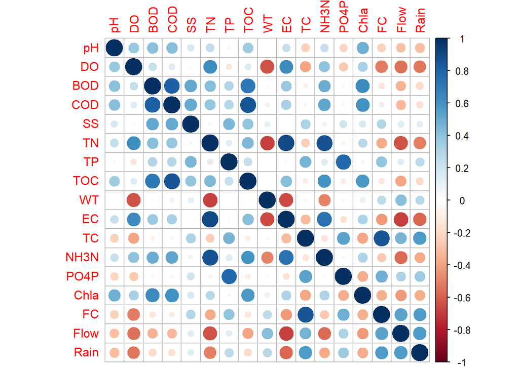

```r
ex1 <- read.csv("C:/Users/HSY/Desktop/광산(2010-2019).csv", sep=",", header=T)
ex1 <- ex1[,-1]
ex1_scale <- scale(ex1)
X1 <- round(cor(ex1_scale, method='spearman'),4)
corrplot(X1)
```

```r
p.mat1 <- cor_pmat(ex1, method='spearman')
```

[output not shown]

[output cut: 352 more lines]

[output not shown]

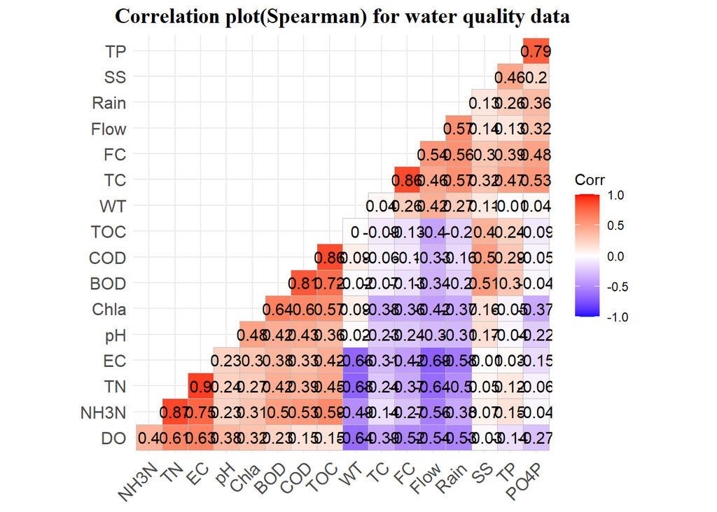

```r
ggcorrplot(X1, hc.order=T, type="lower", lab=T) +
  ggtitle("Correlation plot(Spearman) for water quality data") +
  theme(plot.title = element_text(family = "serif",
                                  face = "bold", hjust = 0.5,
                                  size = 15, color = "black"))
```

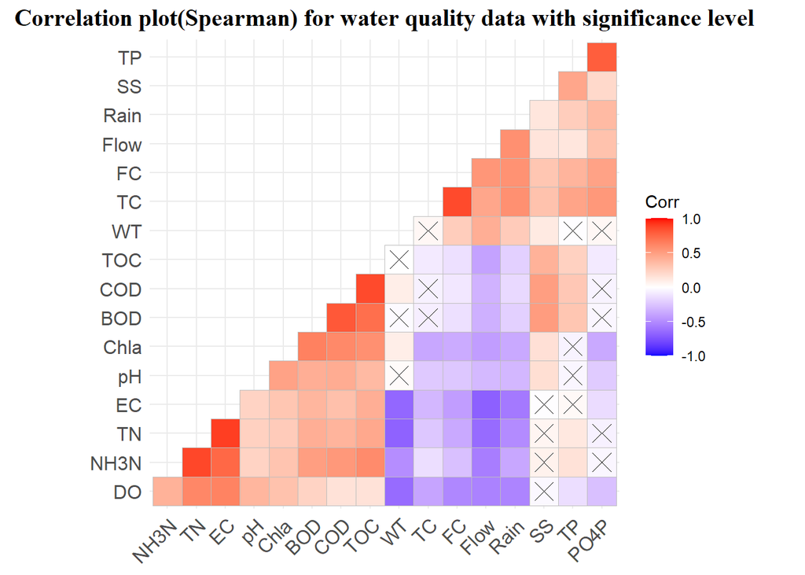

```r
ggcorrplot(X1, hc.order=T, type="lower", p.mat=p.mat1) +
  ggtitle("Correlation plot(Spearman) for water quality data with significance level") +
  theme(plot.title = element_text(family = "serif",
                                  face = "bold", hjust = 0.5,
                                  size = 15, color = "black"))
```

### Multiple Linear Regression

#### scaling data 사용

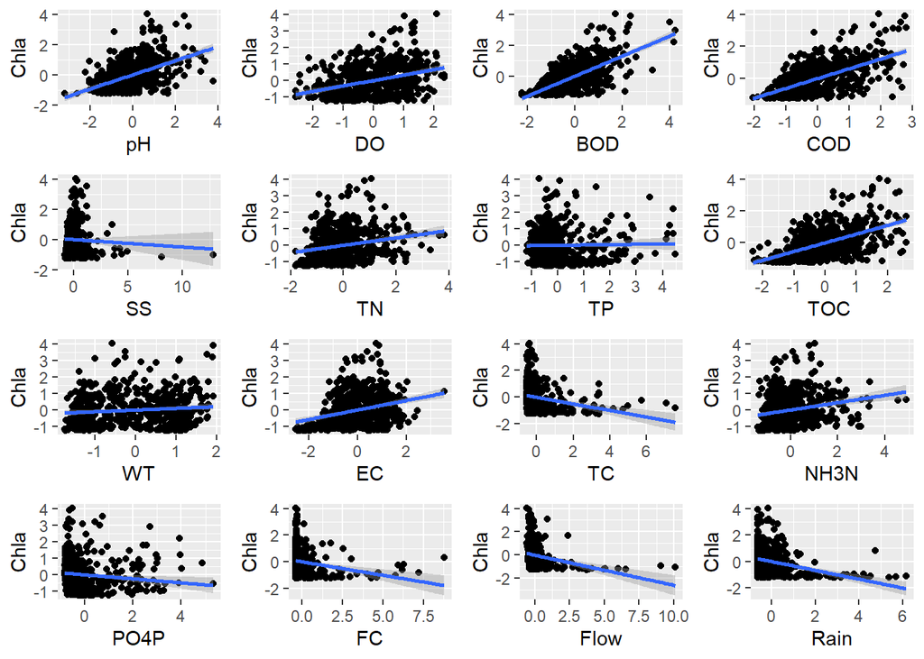

```r
ex1_scale <- as.data.frame(ex1_scale)
p1 <- ggplot(data=ex1_scale,aes(x=pH,y=Chla)) + geom_point() + stat_smooth(method=lm)
p2 <- ggplot(data=ex1_scale,aes(x=DO,y=Chla)) + geom_point() + stat_smooth(method=lm)
p3 <- ggplot(data=ex1_scale,aes(x=BOD,y=Chla)) + geom_point() + stat_smooth(method=lm)
p4 <- ggplot(data=ex1_scale,aes(x=COD,y=Chla)) + geom_point() + stat_smooth(method=lm)
p5 <- ggplot(data=ex1_scale,aes(x=SS,y=Chla)) + geom_point() + stat_smooth(method=lm)
p6 <- ggplot(data=ex1_scale,aes(x=TN,y=Chla)) + geom_point() + stat_smooth(method=lm)
p7 <- ggplot(data=ex1_scale,aes(x=TP,y=Chla)) + geom_point() + stat_smooth(method=lm)
p8 <- ggplot(data=ex1_scale,aes(x=TOC,y=Chla)) + geom_point() + stat_smooth(method=lm)
p9 <- ggplot(data=ex1_scale,aes(x=WT,y=Chla)) + geom_point() + stat_smooth(method=lm)
p10 <- ggplot(data=ex1_scale,aes(x=EC,y=Chla)) + geom_point() + stat_smooth(method=lm)
p11 <- ggplot(data=ex1_scale,aes(x=TC,y=Chla)) + geom_point() + stat_smooth(method=lm)
p12 <- ggplot(data=ex1_scale,aes(x=NH3N,y=Chla)) + geom_point() + stat_smooth(method=lm)
p13 <- ggplot(data=ex1_scale,aes(x=PO4P,y=Chla)) + geom_point() + stat_smooth(method=lm)
p14 <- ggplot(data=ex1_scale,aes(x=FC,y=Chla)) + geom_point() + stat_smooth(method=lm)
p15 <- ggplot(data=ex1_scale,aes(x=Flow,y=Chla)) + geom_point() + stat_smooth(method=lm)
p16 <- ggplot(data=ex1_scale,aes(x=Rain,y=Chla)) + geom_point() + stat_smooth(method=lm)
grid.arrange(p1,p2,p3,p4,p5,p6,p7,p8,p9,p10,p11,p12,p13,p14,p15,p16,nrow=4,ncol=4)
```

```r
fit <- lm(Chla~.,data=ex1_scale)
summary(fit) # Adjusted R-squared:  0.647
```

```
##
## Call:
## lm(formula = Chla ~ ., data = ex1_scale)
##
## Residuals:
##      Min       1Q   Median       3Q      Max
## -2.00834 -0.31703  0.00268  0.27964  2.50540
##
## Coefficients:
##               Estimate Std. Error t value Pr(>|t|)
## (Intercept)  2.553e-16  2.631e-02   0.000  1.00000
## pH           6.053e-02  3.336e-02   1.814  0.07024 .
## DO           3.031e-01  4.493e-02   6.746 4.26e-11 ***
## BOD          4.019e-01  4.724e-02   8.508  < 2e-16 ***
## COD          1.855e-01  6.322e-02   2.935  0.00349 **
## SS          -2.334e-01  4.024e-02  -5.800 1.18e-08 ***
## TN          -1.759e-02  1.007e-01  -0.175  0.86136
## TP           4.588e-01  1.029e-01   4.459 1.02e-05 ***
## TOC          8.582e-02  5.682e-02   1.510  0.13159
## WT           2.217e-01  5.076e-02   4.368 1.53e-05 ***
## EC          -2.026e-02  6.513e-02  -0.311  0.75590
## TC          -1.393e-01  4.439e-02  -3.139  0.00180 **
## NH3N        -1.209e-01  7.324e-02  -1.650  0.09956 .
## PO4P        -5.211e-01  9.424e-02  -5.530 5.21e-08 ***
## FC           4.668e-02  4.301e-02   1.085  0.27832
## Flow         1.655e-02  4.048e-02   0.409  0.68282
## Rain        -5.295e-02  4.006e-02  -1.322  0.18683
## ---
## Signif. codes:  0 '***' 0.001 '**' 0.01 '*' 0.05 '.' 0.1 ' ' 1
##
## Residual standard error: 0.5942 on 493 degrees of freedom
## Multiple R-squared:  0.6581, Adjusted R-squared:  0.647
## F-statistic:  59.3 on 16 and 493 DF,  p-value: < 2.2e-16
```

```r
vif(fit) # 다중공선성(multicollinearity) 존재
```

```
##        pH        DO       BOD       COD        SS        TN        TP       TOC
##  1.604904  2.910999  3.217985  5.761816  2.335179 14.608002 15.265655  4.655024
##        WT        EC        TC      NH3N      PO4P        FC      Flow      Rain
##  3.714202  6.116004  2.840458  7.733994 12.805136  2.667687  2.361970  2.313576
```

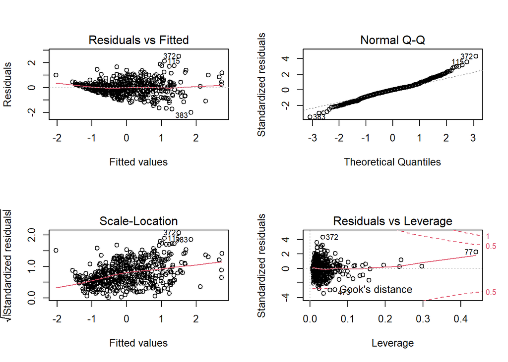

```r
par(mfrow=c(2,2))
plot(fit)
```

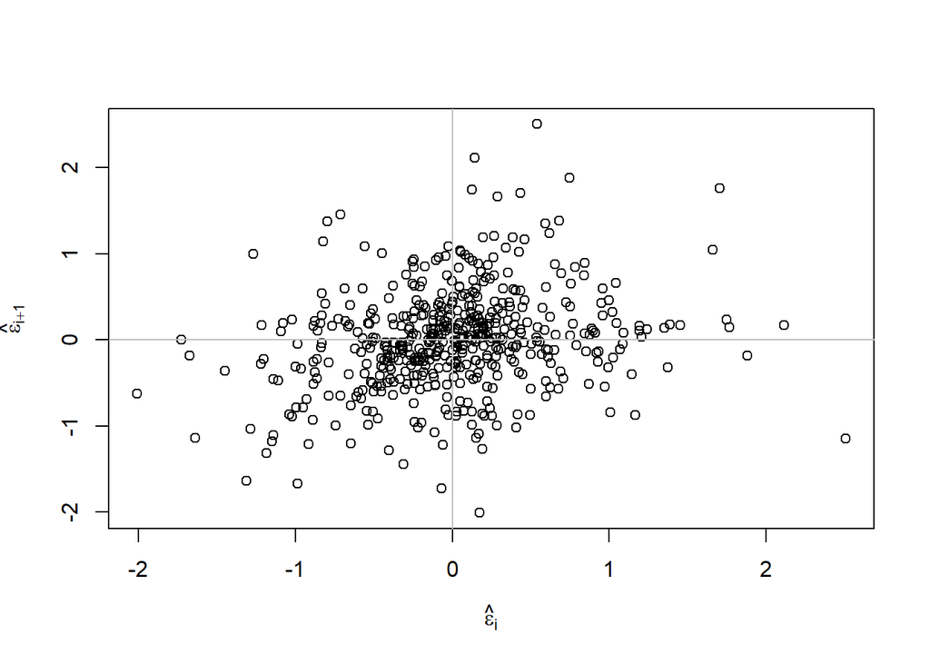

```r
par(mfrow=c(1,1))
n <- length(residuals(fit))
plot(tail(residuals(fit),n-1) ~ head(residuals(fit),n-1), xlab= expression(hat(epsilon)[i]),ylab=expression(hat(epsilon)[i+1]))
abline(h=0,v=0,col=grey(0.75))
```

```r
dwtest(Chla~.,data=ex1_scale) # 잔차가 양의 자기상관성을 가지고 있음.
```

```
##
##  Durbin-Watson test
##
## data:  Chla ~ .
## DW = 1.5389, p-value = 1.551e-08
## alternative hypothesis: true autocorrelation is greater than 0
```

```r
fit1 <- lm(Chla~DO+BOD+COD+SS+TP+WT+TC+PO4P,data=ex1_scale) # 모형 fit에서 유의하지 않은 변수를 제외함.
summary(fit1) # Adjusted R-squared:  0.6405
```

```
##
## Call:
## lm(formula = Chla ~ DO + BOD + COD + SS + TP + WT + TC + PO4P,
##     data = ex1_scale)
##
## Residuals:
##      Min       1Q   Median       3Q      Max
## -1.89809 -0.35714 -0.00493  0.31227  2.45148
##
## Coefficients:
##               Estimate Std. Error t value Pr(>|t|)
## (Intercept)  3.543e-16  2.655e-02   0.000  1.00000
## DO           3.496e-01  3.828e-02   9.132  < 2e-16 ***
## BOD          4.070e-01  4.539e-02   8.966  < 2e-16 ***
## COD          1.967e-01  4.461e-02   4.409 1.27e-05 ***
## SS          -2.230e-01  3.223e-02  -6.917 1.41e-11 ***
## TP           4.698e-01  1.001e-01   4.693 3.48e-06 ***
## WT           3.261e-01  3.696e-02   8.824  < 2e-16 ***
## TC          -9.593e-02  3.035e-02  -3.161  0.00167 **
## PO4P        -5.629e-01  9.226e-02  -6.101 2.11e-09 ***
## ---
## Signif. codes:  0 '***' 0.001 '**' 0.01 '*' 0.05 '.' 0.1 ' ' 1
##
## Residual standard error: 0.5996 on 501 degrees of freedom
## Multiple R-squared:  0.6461, Adjusted R-squared:  0.6405
## F-statistic: 114.3 on 8 and 501 DF,  p-value: < 2.2e-16
```

```r
vif(fit1) # 다중공선성 존재
```

```
##        DO       BOD       COD        SS        TP        WT        TC      PO4P
##  2.074997  2.916882  2.817737  1.471040 14.188340  1.933967  1.303717 12.051006
```

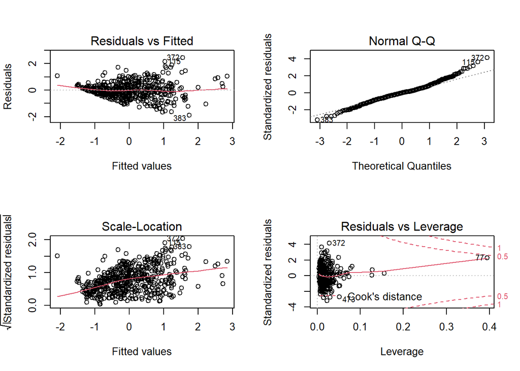

```r
par(mfrow=c(2,2))
plot(fit1)
```

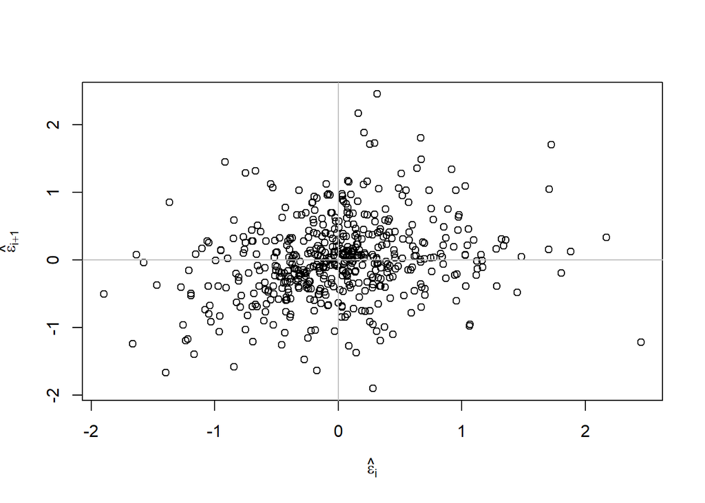

```r
par(mfrow=c(1,1))
n <- length(residuals(fit1))
plot(tail(residuals(fit1),n-1) ~ head(residuals(fit1),n-1), xlab= expression(hat(epsilon)[i]),ylab=expression(hat(epsilon)[i+1]))
abline(h=0,v=0,col=grey(0.75))
```

```r
dwtest(Chla~DO+BOD+COD+SS+TP+WT+TC+PO4P,data=ex1_scale)
```

```
##
##  Durbin-Watson test
##
## data:  Chla ~ DO + BOD + COD + SS + TP + WT + TC + PO4P
## DW = 1.5363, p-value = 2.675e-08
## alternative hypothesis: true autocorrelation is greater than 0
```

```r
# 다중회귀분석에 대한 기본가정인 잔차(residual)에 대한 정규성, 등분산성, 독립성, 선형성 등을 만족하지 못함.
```

### Generalized Additive Model

#### scaling data 사용

```r
# GAM의 경우 추정되는 계수(coefficients)가 데이터의 개수보다 많으면 적합되지 않음.
m <- gam(Chla~s(pH)+s(DO)+s(BOD)+s(COD)+s(SS)+s(TN)+s(TP)+s(TOC)+s(WT)+s(EC)+s(TC)+s(NH3N)+s(PO4P)+s(FC)+s(Flow)+s(Rain),data=ex1_scale)
ggGam(m)
```

```
##  chr "ggGam(model = m)"
## List of 1
##  $ model: chr "m"
```

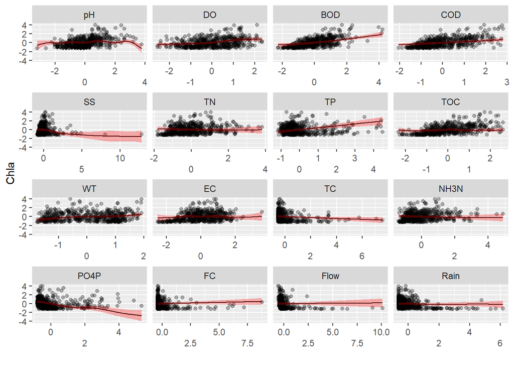

```r
summary(m) # R-sq.(adj) =  0.706
```

```
##
## Family: gaussian
## Link function: identity
##
## Formula:
## Chla ~ s(pH) + s(DO) + s(BOD) + s(COD) + s(SS) + s(TN) + s(TP) +
##     s(TOC) + s(WT) + s(EC) + s(TC) + s(NH3N) + s(PO4P) + s(FC) +
##     s(Flow) + s(Rain)
##
## Parametric coefficients:
##               Estimate Std. Error t value Pr(>|t|)
## (Intercept) -8.544e-12  2.402e-02       0        1
##
## Approximate significance of smooth terms:
##           edf Ref.df      F  p-value
## s(pH)   8.211  8.776  4.072 0.000130 ***
## s(DO)   4.277  5.307 12.149  < 2e-16 ***
## s(BOD)  2.444  3.150 18.463  < 2e-16 ***
## s(COD)  1.000  1.000 13.696 0.000241 ***
## s(SS)   4.822  5.801  6.605 1.96e-06 ***
## s(TN)   1.694  2.128  0.749 0.474935
## s(TP)   1.000  1.000 18.921 1.74e-05 ***
## s(TOC)  6.713  7.790  1.183 0.344086
## s(WT)   3.504  4.384  6.975 1.23e-05 ***
## s(EC)   5.953  7.159  1.175 0.299066
## s(TC)   1.000  1.000  5.801 0.016410 *
## s(NH3N) 1.508  1.839  0.739 0.374540
## s(PO4P) 5.251  6.368  6.788 9.08e-07 ***
## s(FC)   1.000  1.000  1.762 0.185061
## s(Flow) 1.000  1.000  0.103 0.747909
## s(Rain) 3.509  4.364  0.583 0.617055
## ---
## Signif. codes:  0 '***' 0.001 '**' 0.01 '*' 0.05 '.' 0.1 ' ' 1
##
## R-sq.(adj) =  0.706   Deviance explained = 73.6%
## GCV =  0.329  Scale est. = 0.29424   n = 510
```

```r
concurvity(m,full=TRUE) # 공선성 존재
```

```
##                  para     s(pH)     s(DO)    s(BOD)    s(COD)     s(SS)
## worst    7.432415e-19 0.5954189 0.8190403 0.8514893 0.8908702 0.9989751
## observed 7.432415e-19 0.3842231 0.7877090 0.7828863 0.8792335 0.7088642
## estimate 7.432415e-19 0.4760618 0.6967023 0.7427172 0.8214279 0.8166507
##              s(TN)     s(TP)    s(TOC)     s(WT)     s(EC)     s(TC)   s(NH3N)
## worst    0.9534749 0.9705119 0.8565892 0.8660595 0.9556286 0.8633118 0.9218240
## observed 0.9406862 0.9553445 0.4815131 0.8246229 0.7164012 0.7851937 0.9094233
## estimate 0.9113783 0.9212866 0.7703884 0.8002139 0.8338510 0.5997361 0.8522401
##            s(PO4P)     s(FC)   s(Flow)   s(Rain)
## worst    0.9652131 0.8723903 0.9989320 0.8409449
## observed 0.9416725 0.7744256 0.8429155 0.6024819
## estimate 0.9160671 0.6061228 0.7790866 0.7122700
```

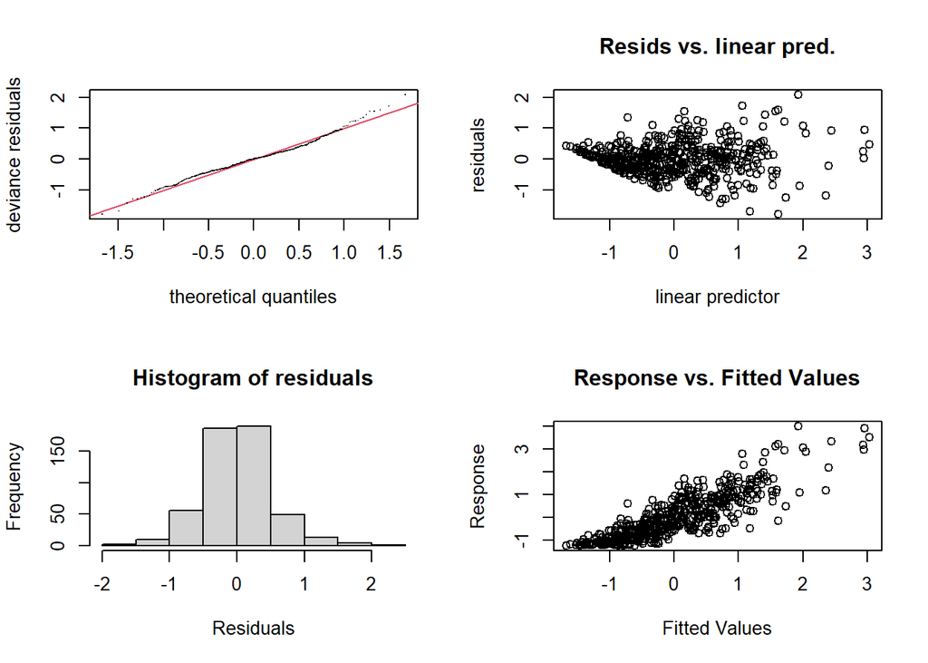

```
##
## Method: GCV   Optimizer: magic
## Smoothing parameter selection converged after 22 iterations.
## The RMS GCV score gradient at convergence was 1.319874e-08 .
## The Hessian was positive definite.
## Model rank =  145 / 145
##
## Basis dimension (k) checking results. Low p-value (k-index<1) may
## indicate that k is too low, especially if edf is close to k'.
##
##           k'  edf k-index p-value
## s(pH)   9.00 8.21    0.89    0.02 *
## s(DO)   9.00 4.28    1.02    0.72
## s(BOD)  9.00 2.44    0.96    0.17
## s(COD)  9.00 1.00    1.01    0.68
## s(SS)   9.00 4.82    0.98    0.26
## s(TN)   9.00 1.69    0.98    0.26
## s(TP)   9.00 1.00    1.05    0.87
## s(TOC)  9.00 6.71    0.93    0.04 *
## s(WT)   9.00 3.50    1.06    0.92
## s(EC)   9.00 5.95    1.03    0.76
## s(TC)   9.00 1.00    0.98    0.36
## s(NH3N) 9.00 1.51    0.97    0.26
## s(PO4P) 9.00 5.25    0.97    0.22
## s(FC)   9.00 1.00    1.10    0.99
## s(Flow) 9.00 1.00    1.01    0.59
## s(Rain) 9.00 3.51    0.97    0.26
## ---
## Signif. codes:  0 '***' 0.001 '**' 0.01 '*' 0.05 '.' 0.1 ' ' 1
```

```r
par(mfrow=c(2,2))
gam.check(m)
```

```r
par(mfrow=c(1,1))
m1 <- gam(Chla~s(pH)+s(DO)+s(BOD)+s(COD)+s(SS)+s(TP)+s(WT)+s(TC)+s(PO4P),data=ex1_scale) # 모형 m에서 유의하지 않은 변수를 제외하고 모형구축.
ggGam(m1)
```

```
##  chr "ggGam(model = m1)"
## List of 1
##  $ model: chr "m1"
```

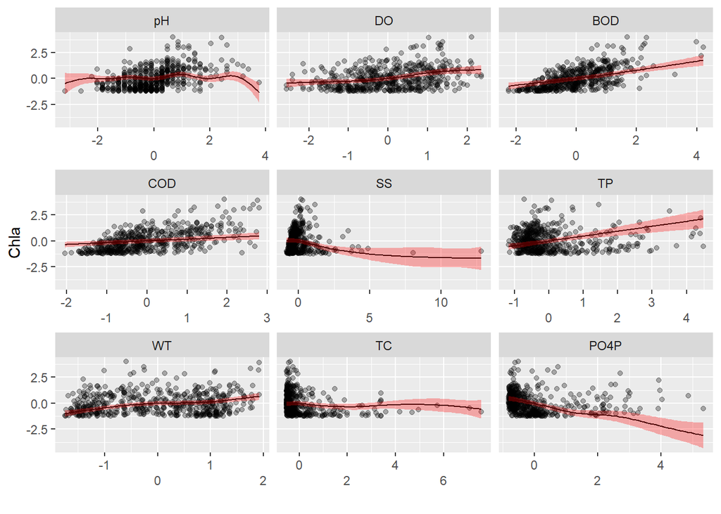

```r
summary(m1) # R-sq.(adj) =  0.691
```

```
##
## Family: gaussian
## Link function: identity
##
## Formula:
## Chla ~ s(pH) + s(DO) + s(BOD) + s(COD) + s(SS) + s(TP) + s(WT) +
##     s(TC) + s(PO4P)
##
## Parametric coefficients:
##             Estimate Std. Error t value Pr(>|t|)
## (Intercept) 2.09e-12   2.46e-02       0        1
##
## Approximate significance of smooth terms:
##           edf Ref.df      F  p-value
## s(pH)   8.171  8.760  3.832 0.000273 ***
## s(DO)   3.859  4.824 14.185  < 2e-16 ***
## s(BOD)  1.848  2.356 28.199  < 2e-16 ***
## s(COD)  1.000  1.000 14.194 0.000186 ***
## s(SS)   4.163  5.073  9.705  < 2e-16 ***
## s(TP)   1.000  1.000 23.829 1.75e-06 ***
## s(WT)   3.814  4.747 17.844  < 2e-16 ***
## s(TC)   4.769  5.787  1.811 0.116028
## s(PO4P) 4.884  5.975  8.502  < 2e-16 ***
## ---
## Signif. codes:  0 '***' 0.001 '**' 0.01 '*' 0.05 '.' 0.1 ' ' 1
##
## R-sq.(adj) =  0.691   Deviance explained = 71.2%
## GCV = 0.33098  Scale est. = 0.30858   n = 510
```

```r
concurvity(m1,full=TRUE) # 공선성 존재
```

```
##                 para     s(pH)     s(DO)    s(BOD)    s(COD)     s(SS)
## worst    5.96143e-19 0.5165263 0.7680029 0.7788710 0.7687278 0.6066620
## observed 5.96143e-19 0.2325637 0.7444783 0.7397720 0.7337106 0.5362396
## estimate 5.96143e-19 0.3676419 0.6195824 0.6612253 0.6631336 0.4175233
##              s(TP)     s(WT)     s(TC)   s(PO4P)
## worst    0.9588697 0.7067540 0.5625044 0.9537055
## observed 0.9421820 0.6955004 0.3040761 0.9292962
## estimate 0.8976915 0.6313241 0.2720255 0.8899985
```

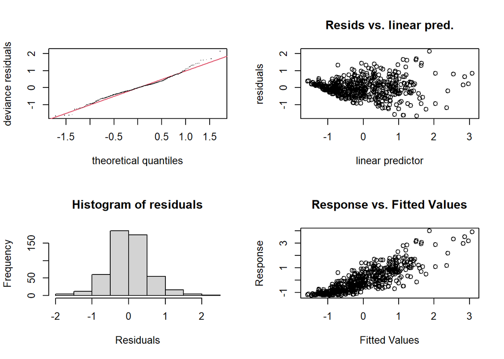

```
##
## Method: GCV   Optimizer: magic
## Smoothing parameter selection converged after 18 iterations.
## The RMS GCV score gradient at convergence was 5.180968e-08 .
## The Hessian was positive definite.
## Model rank =  82 / 82
##
## Basis dimension (k) checking results. Low p-value (k-index<1) may
## indicate that k is too low, especially if edf is close to k'.
##
##           k'  edf k-index p-value
## s(pH)   9.00 8.17    0.87  <2e-16 ***
## s(DO)   9.00 3.86    1.02    0.66
## s(BOD)  9.00 1.85    0.94    0.06 .
## s(COD)  9.00 1.00    1.00    0.44
## s(SS)   9.00 4.16    0.97    0.26
## s(TP)   9.00 1.00    1.06    0.91
## s(WT)   9.00 3.81    1.02    0.70
## s(TC)   9.00 4.77    0.98    0.32
## s(PO4P) 9.00 4.88    0.98    0.33
## ---
## Signif. codes:  0 '***' 0.001 '**' 0.01 '*' 0.05 '.' 0.1 ' ' 1
```

```r
par(mfrow=c(2,2))
gam.check(m1)
```

```r
par(mfrow=c(1,1))
m2 <- gam(Chla~s(pH)+s(DO)+s(BOD)+s(COD)+s(SS)+s(TP)+s(WT)+s(PO4P),data=ex1_scale) # 모형 m1에서 유의하지 않은 변수를 제외하고 모형구축.
ggGam(m2)
```

```
##  chr "ggGam(model = m2)"
## List of 1
##  $ model: chr "m2"
```

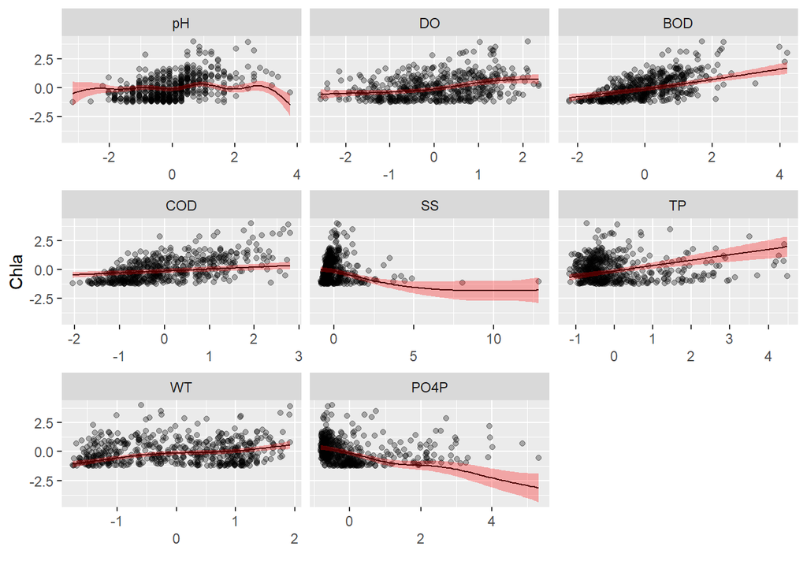

```r
summary(m2) # R-sq.(adj) =  0.686
```

```
##
## Family: gaussian
## Link function: identity
##
## Formula:
## Chla ~ s(pH) + s(DO) + s(BOD) + s(COD) + s(SS) + s(TP) + s(WT) +
##     s(PO4P)
##
## Parametric coefficients:
##              Estimate Std. Error t value Pr(>|t|)
## (Intercept) 2.672e-12  2.481e-02       0        1
##
## Approximate significance of smooth terms:
##           edf Ref.df      F  p-value
## s(pH)   8.227  8.788  3.873 0.000225 ***
## s(DO)   3.894  4.871 15.836  < 2e-16 ***
## s(BOD)  1.816  2.315 31.025  < 2e-16 ***
## s(COD)  1.000  1.000 13.504 0.000265 ***
## s(SS)   3.706  4.546 13.928  < 2e-16 ***
## s(TP)   1.000  1.000 23.180  2.4e-06 ***
## s(WT)   3.712  4.627 19.618  < 2e-16 ***
## s(PO4P) 4.941  6.037  8.997  < 2e-16 ***
## ---
## Signif. codes:  0 '***' 0.001 '**' 0.01 '*' 0.05 '.' 0.1 ' ' 1
##
## R-sq.(adj) =  0.686   Deviance explained = 70.4%
## GCV = 0.33302  Scale est. = 0.31389   n = 510
```

```r
concurvity(m2,full=TRUE)
```

```
##                  para     s(pH)     s(DO)    s(BOD)    s(COD)     s(SS)
## worst    5.890513e-19 0.5096555 0.7400424 0.7712191 0.7636273 0.5576291
## observed 5.890513e-19 0.2077675 0.7199983 0.7328155 0.7294819 0.5090940
## estimate 5.890513e-19 0.3554833 0.5926541 0.6521886 0.6580106 0.3833037
##              s(TP)     s(WT)   s(PO4P)
## worst    0.9574081 0.6838822 0.9521768
## observed 0.9413941 0.6708407 0.9222690
## estimate 0.8958003 0.6034895 0.8855690
```

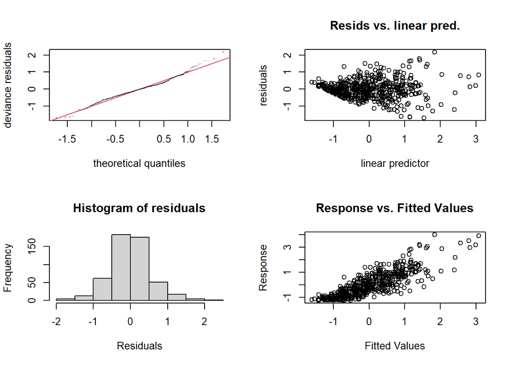

```
##
## Method: GCV   Optimizer: magic
## Smoothing parameter selection converged after 14 iterations.
## The RMS GCV score gradient at convergence was 6.025729e-08 .
## The Hessian was positive definite.
## Model rank =  73 / 73
##
## Basis dimension (k) checking results. Low p-value (k-index<1) may
## indicate that k is too low, especially if edf is close to k'.
##
##           k'  edf k-index p-value
## s(pH)   9.00 8.23    0.86   0.005 **
## s(DO)   9.00 3.89    1.02   0.620
## s(BOD)  9.00 1.82    0.94   0.060 .
## s(COD)  9.00 1.00    0.99   0.395
## s(SS)   9.00 3.71    0.96   0.180
## s(TP)   9.00 1.00    1.07   0.945
## s(WT)   9.00 3.71    1.02   0.645
## s(PO4P) 9.00 4.94    0.98   0.330
## ---
## Signif. codes:  0 '***' 0.001 '**' 0.01 '*' 0.05 '.' 0.1 ' ' 1
```

```r
par(mfrow=c(2,2))
gam.check(m2)
```

```r
par(mfrow=c(1,1))
```

#### 최종선택된 모형의 설명력 : 64.1%(다중선형회귀모형), 68.6%(일반화가법모형) -> 반응변수를 TC로 했을때보다 확실한 차이는 나지 않았음.

#### 일반화가법모형이 다중선형회귀모형보다 설명력이 우수하다는 것을 확실하게 보여주기 위해서는 TC나 FC처럼 설명변수들과 확실한 비선형관계가 있다고 여겨지는 변수를 반응변수로 선택하는 것이 좋다고 판단됨.

### 사용데이터 : 우치 지점 데이터

#### 모니터링 기간 : 2010~2019년 (일별 주단위자료)

#### 반응변수 : Chla

#### 설명변수 : pH, DO, BOD, COD, SS, TN, TP, TOC, WT, EC, TC, NH3N, PO4P, FC, Flow, Rain

#### 수질항목별 단위가 다르다는 점을 감안하여 표준화된 데이터를 사용

### Correlation Analysis

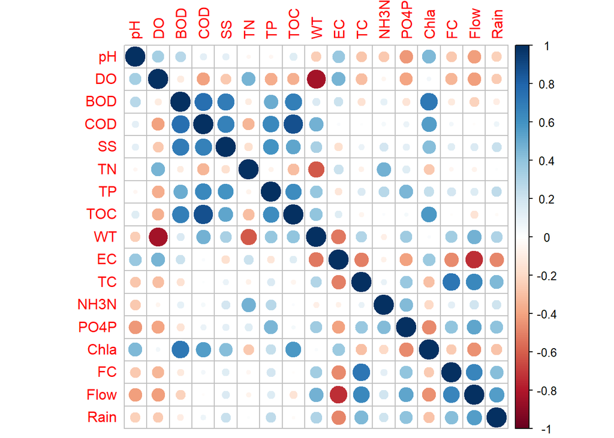

```r
ex2 <- read.csv("C:/Users/HSY/Desktop/우치(2010-2019).csv", sep=",", header=T)
ex2 <- ex2[,-1]
ex2_scale <- scale(ex2)
X2 <- round(cor(ex2_scale, method='spearman'),4)
corrplot(X2)
```

```r
p.mat2 <- cor_pmat(ex2, method='spearman')
```

[output not shown]

[output cut: 352 more lines]

[output not shown]

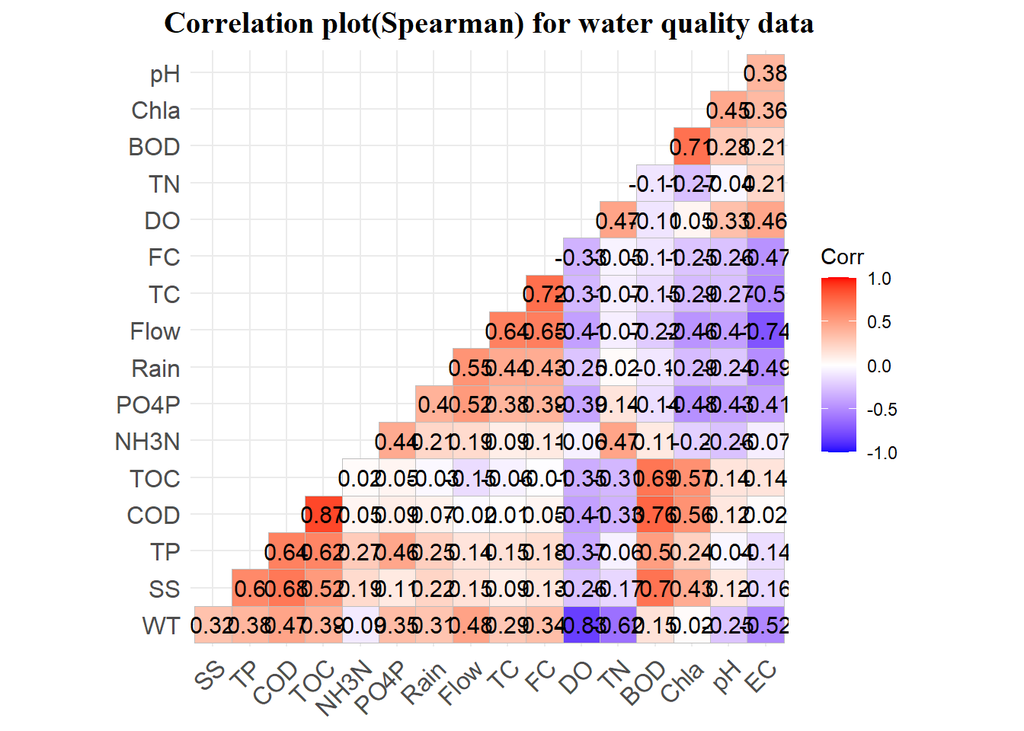

```r
ggcorrplot(X2, hc.order=T, type="lower", lab=T) +
  ggtitle("Correlation plot(Spearman) for water quality data") +
  theme(plot.title = element_text(family = "serif",
                                  face = "bold", hjust = 0.5,
                                  size = 15, color = "black"))
```

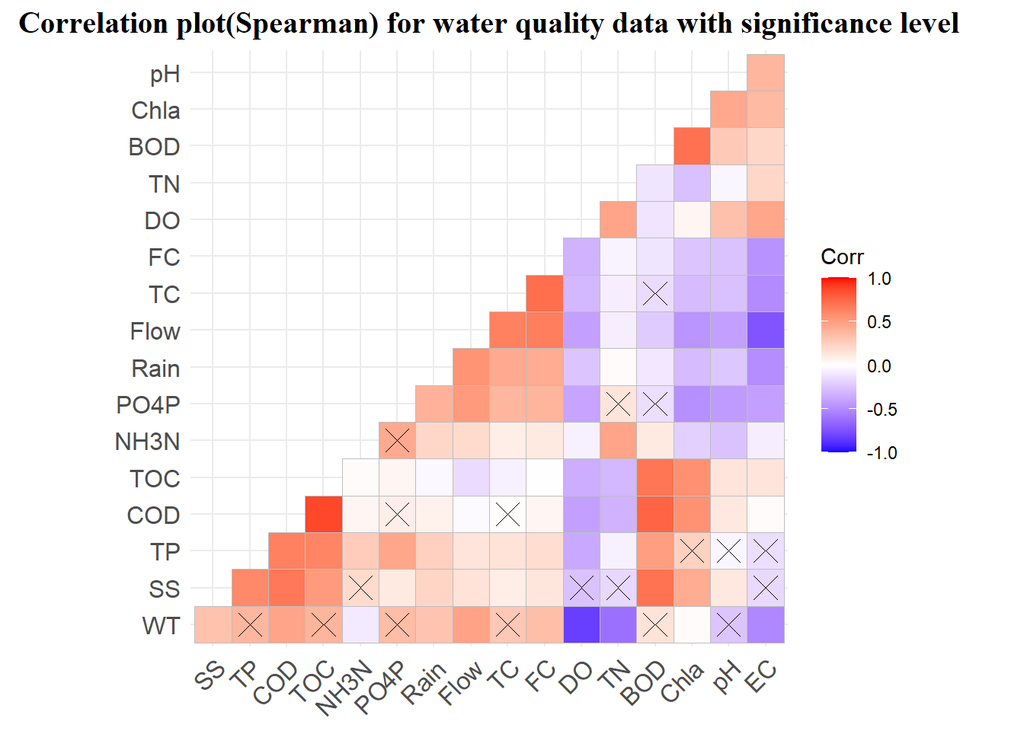

```r
ggcorrplot(X2, hc.order=T, type="lower", p.mat=p.mat1) +
  ggtitle("Correlation plot(Spearman) for water quality data with significance level") +
  theme(plot.title = element_text(family = "serif",
                                  face = "bold", hjust = 0.5,
                                  size = 15, color = "black"))
```

### Multiple Linear Regression

#### scaling data 사용

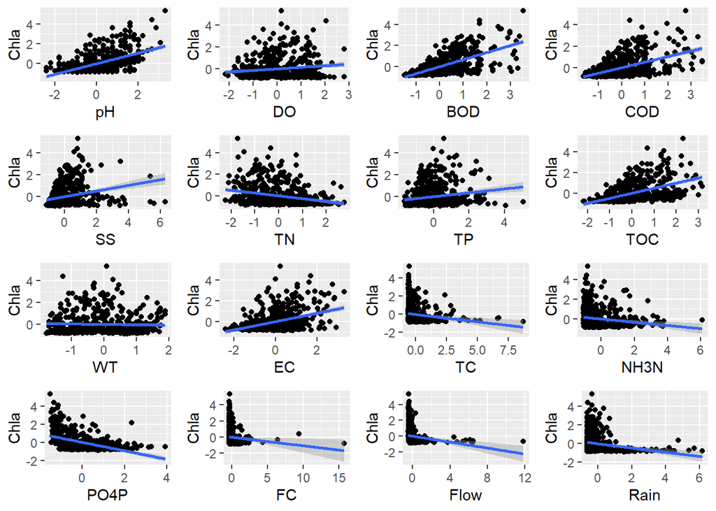

```r
ex2_scale <- as.data.frame(ex2_scale)
g1 <- ggplot(data=ex2_scale,aes(x=pH,y=Chla)) + geom_point() + stat_smooth(method=lm)
g2 <- ggplot(data=ex2_scale,aes(x=DO,y=Chla)) + geom_point() + stat_smooth(method=lm)
g3 <- ggplot(data=ex2_scale,aes(x=BOD,y=Chla)) + geom_point() + stat_smooth(method=lm)
g4 <- ggplot(data=ex2_scale,aes(x=COD,y=Chla)) + geom_point() + stat_smooth(method=lm)
g5 <- ggplot(data=ex2_scale,aes(x=SS,y=Chla)) + geom_point() + stat_smooth(method=lm)
g6 <- ggplot(data=ex2_scale,aes(x=TN,y=Chla)) + geom_point() + stat_smooth(method=lm)
g7 <- ggplot(data=ex2_scale,aes(x=TP,y=Chla)) + geom_point() + stat_smooth(method=lm)
g8 <- ggplot(data=ex2_scale,aes(x=TOC,y=Chla)) + geom_point() + stat_smooth(method=lm)
g9 <- ggplot(data=ex2_scale,aes(x=WT,y=Chla)) + geom_point() + stat_smooth(method=lm)
g10 <- ggplot(data=ex2_scale,aes(x=EC,y=Chla)) + geom_point() + stat_smooth(method=lm)
g11 <- ggplot(data=ex2_scale,aes(x=TC,y=Chla)) + geom_point() + stat_smooth(method=lm)
g12 <- ggplot(data=ex2_scale,aes(x=NH3N,y=Chla)) + geom_point() + stat_smooth(method=lm)
g13 <- ggplot(data=ex2_scale,aes(x=PO4P,y=Chla)) + geom_point() + stat_smooth(method=lm)
g14 <- ggplot(data=ex2_scale,aes(x=FC,y=Chla)) + geom_point() + stat_smooth(method=lm)
g15 <- ggplot(data=ex2_scale,aes(x=Flow,y=Chla)) + geom_point() + stat_smooth(method=lm)
g16 <- ggplot(data=ex2_scale,aes(x=Rain,y=Chla)) + geom_point() + stat_smooth(method=lm)
grid.arrange(g1,g2,g3,g4,g5,g6,g7,g8,g9,g10,g11,g12,g13,g14,g15,g16,nrow=4,ncol=4)
```

```r
gfit <- lm(Chla~.,data=ex2_scale)
summary(gfit) # Adjusted R-squared:  0.7037
```

```
##
## Call:
## lm(formula = Chla ~ ., data = ex2_scale)
##
## Residuals:
##      Min       1Q   Median       3Q      Max
## -2.17445 -0.29333 -0.03992  0.23476  2.39268
##
## Coefficients:
##               Estimate Std. Error t value Pr(>|t|)
## (Intercept)  1.095e-16  2.408e-02   0.000 1.000000
## pH           1.547e-01  2.988e-02   5.179 3.26e-07 ***
## DO           8.918e-02  4.555e-02   1.958 0.050823 .
## BOD          3.761e-01  4.873e-02   7.719 6.57e-14 ***
## COD          1.252e-01  6.166e-02   2.030 0.042878 *
## SS           2.170e-02  4.078e-02   0.532 0.594816
## TN          -2.183e-01  3.945e-02  -5.533 5.11e-08 ***
## TP           1.491e-01  4.268e-02   3.493 0.000521 ***
## TOC          3.217e-02  5.629e-02   0.571 0.567971
## WT          -1.017e-01  5.830e-02  -1.745 0.081668 .
## EC           1.033e-01  3.506e-02   2.946 0.003375 **
## TC          -1.677e-02  3.414e-02  -0.491 0.623500
## NH3N        -5.583e-02  3.076e-02  -1.815 0.070138 .
## PO4P        -3.197e-01  3.896e-02  -8.206 1.99e-15 ***
## FC          -6.026e-03  3.150e-02  -0.191 0.848384
## Flow        -2.874e-02  3.359e-02  -0.856 0.392506
## Rain         7.453e-02  3.372e-02   2.210 0.027562 *
## ---
## Signif. codes:  0 '***' 0.001 '**' 0.01 '*' 0.05 '.' 0.1 ' ' 1
##
## Residual standard error: 0.5444 on 494 degrees of freedom
## Multiple R-squared:  0.713,  Adjusted R-squared:  0.7037
## F-statistic: 76.69 on 16 and 494 DF,  p-value: < 2.2e-16
```

```r
vif(gfit)
```

```
##       pH       DO      BOD      COD       SS       TN       TP      TOC
## 1.536310 3.571344 4.086361 6.544444 2.861876 2.677940 3.135017 5.453656
##       WT       EC       TC     NH3N     PO4P       FC     Flow     Rain
## 5.850559 2.116081 2.006009 1.628595 2.611741 1.707926 1.941513 1.957256
```

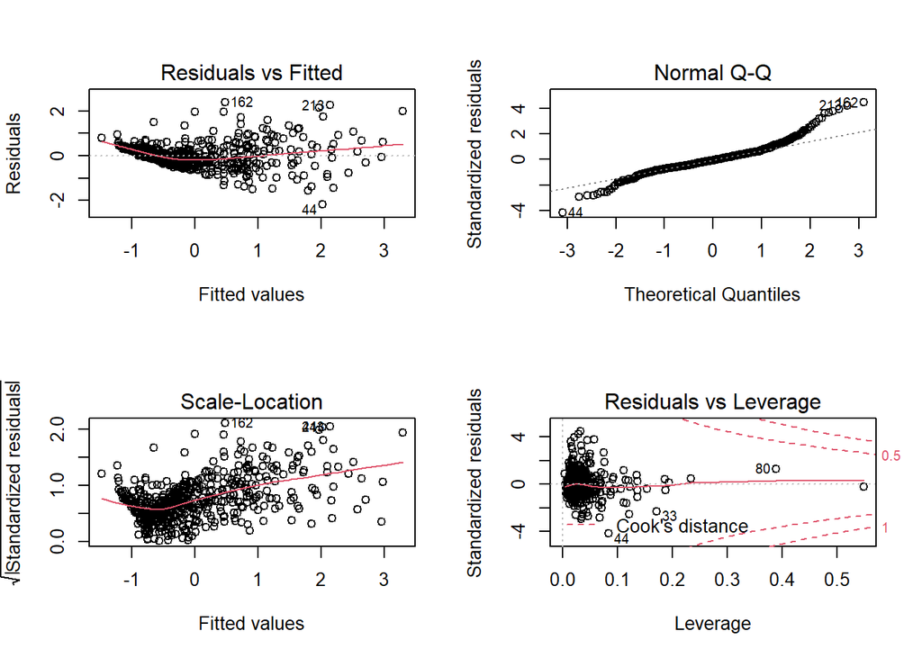

```r
par(mfrow=c(2,2))
plot(gfit)
```